# Uso de API de Covid19 con Pandas

- https://covid19api.com/
- https://api.covid19api.com/

Las URLs anteriores son destinadas al proyecto

Procedemos a instalar la librería Pandas que se basa en un codigo abierto para Python. Esta librería ayuda a manipular grandes datos como Big Data. Gracias a esta herramienta el análisis de datos se agiliza y permite manipular y tratar los datos.

## Instalación Pandas

```python
!pip install pandas
```

# Configuración

Importamos la libería pandas a la cual la llamaremos mediante pd, no como pandas. Utilizaremos esta nomenclatura para llamar a pandas a lo largo del proyecto.

```python
import pandas as pd
```

## Variables

Entre los primeros pasos tenemos la creación de variables. En este caso creamos la variable url para importar la información de los países. Al llamar a la url comprueba el valor de la url.

```python
url = 'https://api.covid19api.com/countries'
url
```

```
'https://api.covid19api.com/countries'
```

## Creación de *Dataframe*

La Api tiene los datos en Json por lo que mediante la función `read_json` leer los datos en este lenguaje.

Utilizamos la función `read_json` de *Pandas* para leer los datos en *JSON* de la API:

El dataframe es una tabla formada por varias series. A esta tabla la llamaremos df. Estará formada mediante la lectura y la url.

Nos conectamos a la tabla de la api seleccionada para importar los datos que demandemos. Esta API nos devuelve los datos en `json`.

En la tabla obtenemos un extracto con cuatro columnas entre las cuales tenemos country, slug e ISO2. Además, la cuarta columna está formada por el índice que pandas no lo considera una columna como tal. El código ISO2 nos ayuda a identificar el código internacional del país.

```python
df = pd.read_json(url)
df
```

|  | Country | Slug | ISO2 |
| --- | --- | --- | --- |
| 0 | Republic of Kosovo | kosovo | XK |
| 1 | Botswana | botswana | BW |
| 2 | Central African Republic | central-african-republic | CF |
| 3 | Hungary | hungary | HU |
| 4 | Peru | peru | PE |
| ... | ... | ... | ... |
| 243 | Malta | malta | MT |
| 244 | San Marino | san-marino | SM |
| 245 | Gibraltar | gibraltar | GI |
| 246 | Uganda | uganda | UG |
| 247 | Vanuatu | vanuatu | VU |

248 rows × 3 columns

## Explorar tabla

- Cabecera
- Cola
- Descripción

Definimos las funciones que vamos a realizar (df.head, df.tail, df.describe). Estas funciones extraen datos de la cabecera y del final. La descripción nos detalla información relevante como el número de países o el primer país de la tabla. La función info está enfocada en la extraccion de datos.

Extrae los 5 primeros datos de la tabla de la API.

```python
df.head()
```

|  | Country | Slug | ISO2 |
| --- | --- | --- | --- |
| 0 | Republic of Kosovo | kosovo | XK |
| 1 | Botswana | botswana | BW |
| 2 | Central African Republic | central-african-republic | CF |
| 3 | Hungary | hungary | HU |
| 4 | Peru | peru | PE |

Extrae los 5 últimos datos de la tabla de la API.

```python
df.tail()
```

|  | Country | Slug | ISO2 |
| --- | --- | --- | --- |
| 243 | Malta | malta | MT |
| 244 | San Marino | san-marino | SM |
| 245 | Gibraltar | gibraltar | GI |
| 246 | Uganda | uganda | UG |
| 247 | Vanuatu | vanuatu | VU |

Esta función nos extrae datos relevantes sobre la tabla. Información descriptiva.

```python
df.describe()
```

|  | Country | Slug | ISO2 |
| --- | --- | --- | --- |
| count | 248 | 248 | 248 |
| unique | 248 | 248 | 248 |
| top | Republic of Kosovo | kosovo | XK |
| freq | 1 | 1 | 1 |

```python
df.info()
```

```
<class 'pandas.core.frame.DataFrame'>
RangeIndex: 248 entries, 0 to 247
Data columns (total 3 columns):
 #   Column   Non-Null Count  Dtype
---  ------   --------------  -----
 0   Country  248 non-null    object
 1   Slug     248 non-null    object
 2   ISO2     248 non-null    object
dtypes: object(3)
memory usage: 5.9+ KB
```

# Acceso a datos

Procedemos a acceder a los datos. Gracias a esta acción podemos leer las diferentes columnas de nuestra tabla. Si conocemos el valor del índice obtenemos el dato del país. Ponemos 'country' para obtener todos los datos de dicha columna.

```python
df['Country']
```

```
0            Republic of Kosovo
1                      Botswana
2      Central African Republic
3                       Hungary
4                          Peru
                 ...
243                       Malta
244                  San Marino
245                   Gibraltar
246                      Uganda
247                     Vanuatu
Name: Country, Length: 248, dtype: object
```

Si conocemos el valor que se corresponde con el índice obtendremos el país.

```python
df['Country'][200]
```

```
'Angola'
```

## Tiempo real en España

```python
url_es = 'https://api.covid19api.com/country/spain/status/confirmed/live'
df_es = pd.read_json(url_es)
df_es
```

|  | Country | CountryCode | Province | City | CityCode | Lat | Lon | Cases | Status | Date |
| --- | --- | --- | --- | --- | --- | --- | --- | --- | --- | --- |
| 0 | Spain | ES |  |  |  | 40.46 | -3.75 | 0 | confirmed | 2020-01-22 00:00:00+00:00 |
| 1 | Spain | ES |  |  |  | 40.46 | -3.75 | 0 | confirmed | 2020-01-23 00:00:00+00:00 |
| 2 | Spain | ES |  |  |  | 40.46 | -3.75 | 0 | confirmed | 2020-01-24 00:00:00+00:00 |
| 3 | Spain | ES |  |  |  | 40.46 | -3.75 | 0 | confirmed | 2020-01-25 00:00:00+00:00 |
| 4 | Spain | ES |  |  |  | 40.46 | -3.75 | 0 | confirmed | 2020-01-26 00:00:00+00:00 |
| ... | ... | ... | ... | ... | ... | ... | ... | ... | ... | ... |
| 794 | Spain | ES |  |  |  | 40.46 | -3.75 | 11451676 | confirmed | 2022-03-26 00:00:00+00:00 |
| 795 | Spain | ES |  |  |  | 40.46 | -3.75 | 11451676 | confirmed | 2022-03-27 00:00:00+00:00 |
| 796 | Spain | ES |  |  |  | 40.46 | -3.75 | 11451676 | confirmed | 2022-03-28 00:00:00+00:00 |
| 797 | Spain | ES |  |  |  | 40.46 | -3.75 | 11508309 | confirmed | 2022-03-29 00:00:00+00:00 |
| 798 | Spain | ES |  |  |  | 40.46 | -3.75 | 11508309 | confirmed | 2022-03-30 00:00:00+00:00 |

799 rows × 10 columns

El float hace alusión a los decimales e int a los números enteros. Object se centra en leer el texto y UTC es el horario que se registra actualmente.

```python
df_es.info()
```

```
<class 'pandas.core.frame.DataFrame'>
RangeIndex: 799 entries, 0 to 798
Data columns (total 10 columns):
 #   Column       Non-Null Count  Dtype
---  ------       --------------  -----
 0   Country      799 non-null    object
 1   CountryCode  799 non-null    object
 2   Province     799 non-null    object
 3   City         799 non-null    object
 4   CityCode     799 non-null    object
 5   Lat          799 non-null    float64
 6   Lon          799 non-null    float64
 7   Cases        799 non-null    int64
 8   Status       799 non-null    object
 9   Date         799 non-null    datetime64[ns, UTC]
dtypes: datetime64[ns, UTC](1), float64(2), int64(1), object(6)
memory usage: 62.5+ KB
```

Convertimos la columna de fecha en la columna de índice. Esto nos sirve para encontrar los datos deseados con más rapidez, así aprovechamos la columna de control de pandas. La función set_index la aplicamos al dataframe de España y le obliga a que el índice sea la columna fecha.

```python
df_es.set_index('Date')
```

| Date | Country | CountryCode | Province | City | CityCode | Lat | Lon | Cases | Status |
| --- | --- | --- | --- | --- | --- | --- | --- | --- | --- |
| 2020-01-22 00:00:00+00:00 | Spain | ES |  |  |  | 40.46 | -3.75 | 0 | confirmed |
| 2020-01-23 00:00:00+00:00 | Spain | ES |  |  |  | 40.46 | -3.75 | 0 | confirmed |
| 2020-01-24 00:00:00+00:00 | Spain | ES |  |  |  | 40.46 | -3.75 | 0 | confirmed |
| 2020-01-25 00:00:00+00:00 | Spain | ES |  |  |  | 40.46 | -3.75 | 0 | confirmed |
| 2020-01-26 00:00:00+00:00 | Spain | ES |  |  |  | 40.46 | -3.75 | 0 | confirmed |
| ... | ... | ... | ... | ... | ... | ... | ... | ... | ... |
| 2022-03-26 00:00:00+00:00 | Spain | ES |  |  |  | 40.46 | -3.75 | 11451676 | confirmed |
| 2022-03-27 00:00:00+00:00 | Spain | ES |  |  |  | 40.46 | -3.75 | 11451676 | confirmed |
| 2022-03-28 00:00:00+00:00 | Spain | ES |  |  |  | 40.46 | -3.75 | 11451676 | confirmed |
| 2022-03-29 00:00:00+00:00 | Spain | ES |  |  |  | 40.46 | -3.75 | 11508309 | confirmed |
| 2022-03-30 00:00:00+00:00 | Spain | ES |  |  |  | 40.46 | -3.75 | 11508309 | confirmed |

799 rows × 9 columns

Otros datos que queremos obtener son los casos. Por ello, los solicitamos mediante la llamada a la columna 'Cases'. Esta llamada comienza en el dataframe.

Mediante la siguiente acción llamamos a los casos y la fecha y le colocamos un título para identificar la tabla.

df_es.set_index('Date')['Cases']

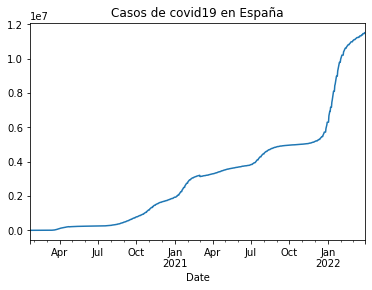

```python
df_es.set_index('Date')['Cases'].plot(title='Casos de covid19 en España')
```

## Tiempo real en Colombia

Definimos la url de Colombia y el dataframe de Colombia. Mediate esta acción obtenemos los datos de dicha tabla. Al definir 'Date' y 'Cases' obtenemos el gráfico de los datos de covid19 en Colombia.

```python
url_co = 'https://api.covid19api.com/country/colombia/status/confirmed/live'
df_co = pd.read_json(url_co)
```

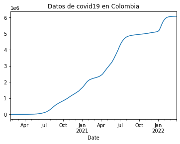

```python
df_co.set_index('Date')['Cases'].plot(title="Datos de covid19 en Colombia")
```